# GLMM example 9

Murray Logan

26 September, 2022

# Preparations

Load the necessary libraries

```r
library(car)       #for regression diagnostics
library(broom)     #for tidy output
library(broom.mixed) #for tidy output
library(ggfortify) #for model diagnostics
library(sjPlot)    #for outputs
library(knitr)     #for kable
library(effects)   #for partial effects plots
library(ggeffects) #for effects plots in ggplotjk
library(emmeans)   #for estimating marginal means
library(MASS)      #for glm.nb
library(MuMIn)     #for AICc
library(tidyverse) #for data wrangling
library(DHARMa)    #for assessing dispersion etc
library(glmmTMB)    #for glmmTMB
library(performance) #for diagnostic plots
library(see)         #for diagnostic plots
library(ordinal)    #for ordinal models
```

```r
hughes = read_csv('../public/data/hughes_full.csv', trim_ws=TRUE)
glimpse(hughes)
```

```
## Rows: 7,196
## Columns: 11
## $ Year        <dbl> 2016, 2016, 2016, 2016, 2016, 2016, 2016, 2016, 2016, 2016…
## $ ReefID      <chr> "09-357", "09-357", "09-357", "09-357", "09-357", "09-366"…
## $ ReefName    <chr> "Mutacomai and Dagagota Reefs", "Mutacomai and Dagagota Re…
## $ Long        <dbl> 143.1977, 143.1977, 143.1977, 143.1977, 143.1977, 143.3132…
## $ Lat         <dbl> -9.285727, -9.285727, -9.285727, -9.285727, -9.285727, -9.…
## $ DHW5k       <dbl> 8.454476, 8.454476, 8.454476, 8.454476, 8.454476, 7.924551…
## $ Sector      <chr> "North", "North", "North", "North", "North", "North", "Nor…
## $ SectorThree <chr> "North", "North", "North", "North", "North", "North", "Nor…
## $ SectorFour  <chr> "FarNorth", "FarNorth", "FarNorth", "FarNorth", "FarNorth"…
## $ Score       <dbl> 4, 4, 4, 4, 4, 3, 3, 3, 3, 3, 4, 4, 4, 4, 4, 4, 4, 4, 1, 1…
## $ Habitat     <chr> "C", "C", "F", "F", "U", "C", "L", "C", "C", "L", "C", "C"…
```

| Bleaching Score | 2016 Equates to | 2017 Equates to |
| --- | --- | --- |
| 0 | No bleaching | No bleaching |
| 1 | 0-10% bleaching | 0-10% bleaching |
| 2 | 10-30% bleaching | 10-30% bleaching |
| 3 | 30-60% bleaching | 30-60% bleaching |
| 4 | > 60% bleaching | 60-80% bleaching |
| 5 | - | > 80% bleaching |

# Data processing

- Make a categorical version of Year
- Combine Scores 4 and 5 into a single Score of 4 to be consistent across years
- Make Score an ordered categorical variable
- Generate a numeric version of categorical Score (as required for the `ocat` family. Note this must be a 1 indexed numeric.
- Relevel Sector such that it is in the order North, Central, South
- Ensure that there is a categorical version of Reef
- Generate a numeric version of the categorical Reef

```r
hughes = hughes %>%
    mutate(fYear=factor(Year),
           Score=ifelse(Score==5,4,Score),
           oScore = factor(Score, ordered=TRUE),
           nScore = as.numeric(factor(Score, ordered=TRUE)),
           SectorThree=factor(SectorThree, levels=c('North','Central','South')),
           fReef=factor(ReefID),
           nReef=as.numeric(fReef))
# now make a version that is just 2016
hughes <- hughes %>% filter(fYear==2016) %>%
    dplyr::select(REEF=ReefID, HABITAT=Habitat, SECTOR=SectorThree, SCORE=Score)
write_csv(hughes, file='../public/data/hughes.csv')
## hughes.colors = c('#FFFFFF', rev(heat.colors(length(levels(hughes$oScore))))[-1])
```

# Read in the data

2016 data only

```r
hughes = read_csv('../public/data/hughes.csv', trim_ws=TRUE)
glimpse(hughes)
```

```
## Rows: 3,394
## Columns: 4
## $ REEF    <chr> "09-357", "09-357", "09-357", "09-357", "09-357", "09-366", "0…
## $ HABITAT <chr> "C", "C", "F", "F", "U", "C", "L", "C", "C", "L", "C", "C", "U…
## $ SECTOR  <chr> "North", "North", "North", "North", "North", "North", "North",…
## $ SCORE   <dbl> 4, 4, 4, 4, 4, 3, 3, 3, 3, 3, 4, 4, 4, 4, 4, 4, 4, 4, 1, 1, 2,…
```

[output not shown]

# Data preparation

- ensure score is ordinal
- declare categorical variables as factors - and relevel sector
- declare random effects as factors

```r
hughes = hughes %>%
    mutate(oSCORE = factor(SCORE, ordered=TRUE),
           HABITAT = factor(HABITAT),
           SECTOR=factor(SECTOR, levels=c('North','Central','South')),
           REEF=factor(REEF))
## hughes.colors = c('#FFFFFF', rev(heat.colors(length(levels(hughes$oSCORE))))[-1])
```

# Exploratory Data Analysis

Proportional (cumulative link) odds-ratio models are useful when the latent (unmeasured) response is recorded on a ordinal (ordered categorical) scale. When this is the case, we can calculate the probability of a that an observed ordinal score ($y$) is less than or equal to any given level ($i$: category) given a set of covariates ($\boldsymbol{X}$) according to the following:

$$Pr(y\le i|\boldsymbol{X}) =
\frac{1}{1+e^{-(\theta_i - \boldsymbol{\beta}.\boldsymbol{X})}}\\$$

where $y$ is the observed categorical response, $\boldsymbol{X}$ is a ($n \times p$) effects model matrix, $\boldsymbol{\beta}$ are the $p$ effects parameters and $\theta_i$ are the $K-1$ category thresholds

- count the number of samples in each bleaching category per sector per habitat
- express this number as proportions
- reverse the order of the score levels

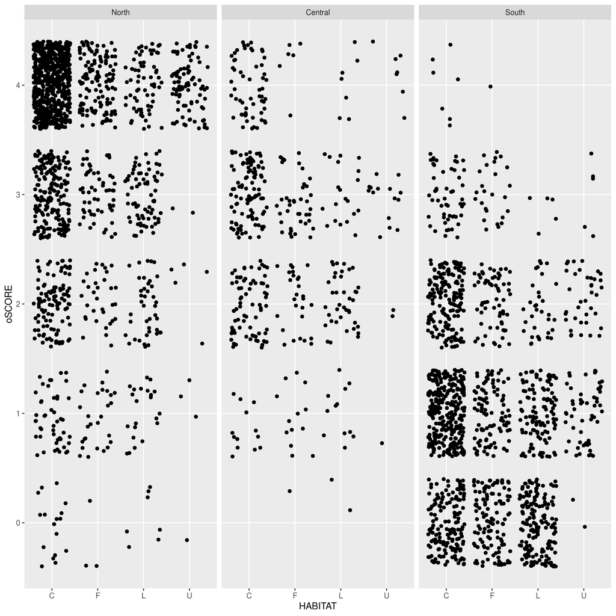

```r
# Scatterplot
hughes %>%
    ggplot(aes(y = oSCORE, x = HABITAT)) +
    geom_point(position = position_jitter()) +
    facet_wrap(~SECTOR)
```

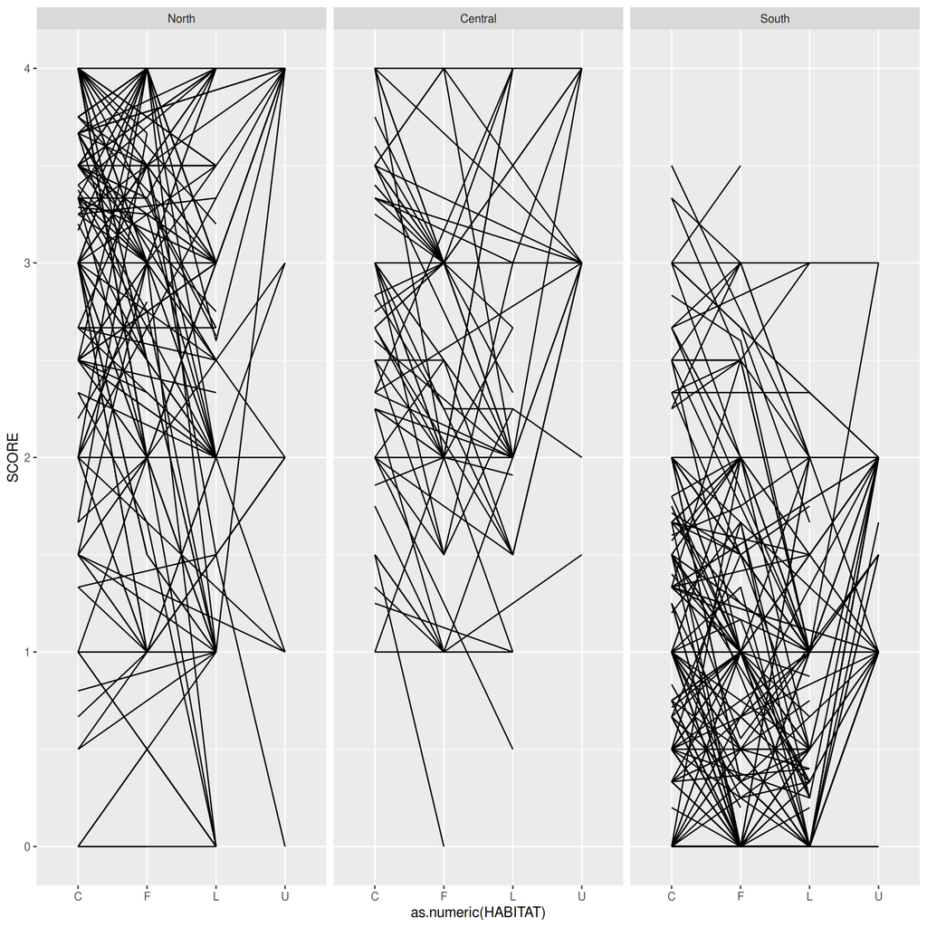

```r
# Line plot - too messy to make much of this...
hughes %>%
    group_by(SECTOR, REEF, HABITAT) %>%
    summarise(SCORE = mean(SCORE)) %>%
    ungroup() %>%
    ggplot(aes(y = SCORE, x = as.numeric(HABITAT), group = REEF)) +
    geom_blank(aes(x = HABITAT)) +
    geom_line() +
    facet_grid(~SECTOR)
```

```r
hughes %>%
    group_by(SECTOR, HABITAT, oSCORE) %>%
    summarise(n = n()) %>%
    ungroup() %>%
    group_by(SECTOR, HABITAT) %>%
    mutate(prop = n/sum(n)) %>%
    mutate(oSCORE = factor(oSCORE, levels = rev(levels(oSCORE)))) ->
    hughes.sum
## hughes.sum <- hughes %>%
##     count(SECTOR,HABITAT,oSCORE) %>%
##     group_by(SECTOR, HABITAT) %>%
##     mutate(prop=prop.table(n),
##            oSCORE=factor(oSCORE, levels=rev(levels(oSCORE))))

hughes.sum %>% head
```

| SECTOR | HABITAT | oSCORE | n | prop |
| --- | --- | --- | --- | --- |
| North | C | 0 | 17 | 0.01717172 |
| North | C | 1 | 47 | 0.04747475 |
| North | C | 2 | 110 | 0.11111111 |
| North | C | 3 | 191 | 0.19292929 |
| North | C | 4 | 625 | 0.63131313 |
| North | F | 0 | 3 | 0.01209677 |

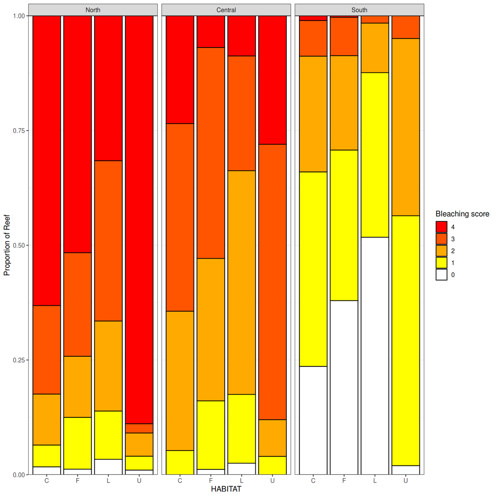

```r
ggplot(data=hughes.sum, aes(y=prop, x=HABITAT)) +
    geom_bar(stat='Identity', aes(fill=oSCORE), color='black') +
    facet_grid(~SECTOR) +
    ## scale_fill_manual('Bleaching score', values=rev(hughes.colors) ) +
    scale_fill_manual('Bleaching score', values=c(heat.colors(5)[-5], '#FFFFFF') ) +
    scale_y_continuous('Proportion of Reef', expand=c(0,0))+
    theme_bw() +
    theme(panel.spacing.y=unit(10,'pt'))
```